# Academic Environments: How Parental Warmth Shapes Student Self-Efficacy and Motivation

PSY 120L Feedback Study Report

Author

Curran Hoxie

Published

June 3, 2026

## About This Report

This report documents the data analysis for our PSY 120L study on academic feedback and student motivation. We walk through each step of the process, from importing and cleaning the data to scoring scales, running ANOVAs, and visualizing the results. All analyses were done in R and can be fully reproduced using the software details at the end of this document.

## Study Overview

This study investigated whether the type of feedback a professor gives affects how students feel about their own abilities and motivation to succeed academically. Participants were randomly assigned to read either an autonomy-supportive or controlling feedback scenario. We measured self-efficacy using the General Self-Efficacy Scale (GSE) and achievement motivation using the Rays Academic Motivation Scale (RAMS). We also looked at whether perceived parental warmth, assessed with the Parenting Assessment Questionnaire (PAQ) and split into high and low groups, moderated these effects. A 2 × 2 between-subjects ANOVA was used to test all main effects and the interaction.

## Setup and Software Environment

The listed packages were loaded for the purposes of data processing, scale construction, statistical analysis, and visualization throughout this report.

**Load Packages**

```r
library(tidyverse)  # data manipulation + plotting
library(psych)      # scale construction + reliability
library(afex)       # ANOVA models + effect sizes
library(emmeans)    # estimated marginal means + confidence intervals
```

## Data Source and Analysis Dataset

The data collected for our study was gathered using Qualtrics. The data was imported into R as a CSV file to be organized and undergo analysis.

### Import Dataset

```r
study_raw <- read_csv("Group 7 Developmental Autonomy_clean.csv") %>%
  rename_with(~ str_replace_all(., " ", "")) %>%
  rename_with(~ tolower(.))
```

### Check Imported Dataset

```r
dim(study_raw)
```

```
[1] 108  66
```

```r
names(study_raw)
```

```
 [1] "responseid"          "distributionchannel" "consent"
 [4] "controlwriting"      "autonomywriting"     "gse_1"
 [7] "gse_2"               "gse_3"               "gse_4"
[10] "gse_5"               "gse_6"               "gse_7"
[13] "gse_8"               "gse_9"               "gse_10"
[16] "rams_1"              "rams_2"              "rams_3"
[19] "rams_4"              "rams_5"              "rams_6"
[22] "rams_7"              "rams_8"              "rams_9"
[25] "rams_10"             "rams_11"             "rams_12"
[28] "rams_13"             "rams_14"             "paq1_1"
[31] "paq1_2"              "paq1_3"              "paq1_4"
[34] "paq1_5"              "paq1_6"              "paq1_7"
[37] "paq1_8"              "paq1_9"              "paq1_10"
[40] "paq1_11"             "paq1_12"             "paq1_13"
[43] "paq1_14"             "paq1_15"             "paq2_1"
[46] "paq2_2"              "paq2_3"              "paq2_4"
[49] "paq2_5"              "paq2_6"              "paq2_7"
[52] "paq2_8"              "paq2_9"              "paq2_10"
[55] "paq2_11"             "paq2_12"             "paq2_13"
[58] "paq2_14"             "paq2_15"             "age"
[61] "gender"              "gender_4_text"       "year"
[64] "year_5_text"         "debrief"             "condition"
```

```r
head(study_raw)
```

| responseid | distributionchannel | consent | controlwriting | autonomywriting | gse_1 | gse_2 | gse_3 | gse_4 | gse_5 | gse_6 | gse_7 | gse_8 | gse_9 | gse_10 | rams_1 | rams_2 | rams_3 | rams_4 | rams_5 | rams_6 | rams_7 | rams_8 | rams_9 | rams_10 | rams_11 | rams_12 | rams_13 | rams_14 | paq1_1 | … |
| --- | --- | --- | --- | --- | --- | --- | --- | --- | --- | --- | --- | --- | --- | --- | --- | --- | --- | --- | --- | --- | --- | --- | --- | --- | --- | --- | --- | --- | --- | --- |
| R_7KOR2s3Am6wuIsh | anonymous | 1 | NA | Receiving this feedback would make me second guess my writing, but ultimately, I would do what is best in my opinion after rereading my draft. This is both ambiguous and not very helpful. | 4 | 3 | 4 | 4 | 4 | 4 | 4 | 4 | 4 | 4 | 2 | 3 | 1 | 1 | 1 | 1 | 3 | 2 | 1 | 1 | 3 | 3 | 3 | 3 | 1 | … |
| R_5HEJrS3Dpv5O1Nf | anonymous | 1 | I would take this feedback and rework my thesis draft. Personally, I'd make a copy and leave my work, which is more concise and easier for me to read, but I would adhere to the professor's advice of m… | NA | 3 | 2 | 3 | 3 | 3 | 3 | 2 | 3 | 3 | 3 | 2 | 1 | 1 | 1 | 3 | 2 | 2 | 1 | 2 | 2 | 2 | 2 | 3 | 2 | 2 | … |
| R_1BscAKP7SLvVrVf | email | 1 | NA | I would feel slightly anxious. If I truly thought that the way I wrote it was best, I would feel really stressed about not talking their feedback. | 3 | 3 | 3 | 3 | 4 | 4 | 2 | 3 | 2 | 3 | 1 | 2 | 1 | 1 | 1 | 2 | 1 | 1 | 1 | 3 | 3 | 3 | 3 | 3 | 2 | … |
| R_5D15R84Vc2nR9sq | email | 1 | I feel somewhat defeated because it does not feel good to be told you did something wrong and have to redo it. | NA | 3 | 2 | 3 | 3 | 3 | 3 | 2 | 3 | 3 | 3 | 1 | 3 | 3 | 3 | 1 | 3 | 1 | 3 | 3 | 2 | 3 | 1 | 3 | 1 | 3 | … |
| R_1ZHTOlNvXCFZj7i | email | 1 | NA | I would feel good about it, since the professor is okay with me choosing how i want to format. | 4 | 3 | 4 | 2 | 3 | 4 | 2 | 3 | 4 | 3 | 1 | 2 | 1 | 3 | 1 | 1 | 2 | 1 | 1 | 2 | 3 | 2 | 1 | 3 | 3 | … |
| R_3xz1r04h0Dgwf5K | anonymous | 1 | NA | I would take this feedback as she explained why I should change my work. It is not offensive at all and very contructive | 3 | 2 | 4 | 4 | 3 | 4 | 4 | 3 | 3 | 4 | 2 | 3 | 3 | 2 | 1 | 1 | 1 | 1 | 1 | 1 | 2 | 3 | 3 | 2 | 4 | … |

The raw data set consists of 108 rows and 66 columns. Column names include participant identifiers, condition assignment, consent status, and all item-level responses for the GSE, RAMS, and PAQ measures. Each row presents the survey responses of one participant.

### Create Analysis Dataset

```r
study_vars <- c(
  "condition", "age", "gender", "year",

  "gse_1", "gse_2", "gse_3", "gse_4", "gse_5", "gse_6",
  "gse_7", "gse_8", "gse_9", "gse_10",

  "rams_1", "rams_2", "rams_3", "rams_4", "rams_5", "rams_6",
  "rams_7", "rams_8", "rams_9", "rams_10", "rams_11", "rams_12",
  "rams_13", "rams_14",

  "paq1_1", "paq1_2", "paq1_3", "paq1_4", "paq1_5", "paq1_6",
  "paq1_7", "paq1_8", "paq1_9", "paq1_10", "paq1_11", "paq1_12",
  "paq1_13", "paq1_14", "paq1_15",

  "paq2_1", "paq2_2", "paq2_3", "paq2_4", "paq2_5", "paq2_6",
  "paq2_7", "paq2_8", "paq2_9", "paq2_10", "paq2_11", "paq2_12",
  "paq2_13", "paq2_14", "paq2_15"
)


rams_items_raw <- paste0("rams_", 1:14)
paq_items <- c(paste0("paq1_", 1:15), paste0("paq2_", 1:15))

study_data <- study_raw %>%
  select(all_of(study_vars)) %>%
  mutate(across(-condition, as.numeric)) %>%
  filter(if_all(all_of(paq_items), ~ !is.na(.))) %>%
  filter(if_all(all_of(rams_items_raw), ~ !is.na(.)))
```

```r
sum(!complete.cases(study_data[, grep("^RAMS_|^PAQ", names(study_data))]))
```

```
[1] 0
```

### Check Analysis Dataset

```r
length(study_vars)
```

```
[1] 58
```

```r
dim(study_data)
```

```
[1] 76 58
```

```r
names(study_data)
```

```
 [1] "condition" "age"       "gender"    "year"      "gse_1"     "gse_2"
 [7] "gse_3"     "gse_4"     "gse_5"     "gse_6"     "gse_7"     "gse_8"
[13] "gse_9"     "gse_10"    "rams_1"    "rams_2"    "rams_3"    "rams_4"
[19] "rams_5"    "rams_6"    "rams_7"    "rams_8"    "rams_9"    "rams_10"
[25] "rams_11"   "rams_12"   "rams_13"   "rams_14"   "paq1_1"    "paq1_2"
[31] "paq1_3"    "paq1_4"    "paq1_5"    "paq1_6"    "paq1_7"    "paq1_8"
[37] "paq1_9"    "paq1_10"   "paq1_11"   "paq1_12"   "paq1_13"   "paq1_14"
[43] "paq1_15"   "paq2_1"    "paq2_2"    "paq2_3"    "paq2_4"    "paq2_5"
[49] "paq2_6"    "paq2_7"    "paq2_8"    "paq2_9"    "paq2_10"   "paq2_11"
[55] "paq2_12"   "paq2_13"   "paq2_14"   "paq2_15"
```

## Variable Preparation

Several steps of variable preparation were completed before analysis. The scale scores were computed by summing the participants’ responses at the item level for self-efficacy (GSE), achievement motivation (RAMS), and perceived parental warmth (PAQ). Perceived parental warmth was the moderator variable obtained from the subscales of the PAQ and divided into high and low groups. Also, a unique participant identifier was added to each case for ANOVA modelling.

### Prepare Participant ID and Experimental Condition

```r
study_data <- study_data %>%
  mutate(
    id = row_number(),
    condition = factor(condition)
  )
```

Row numbers were used to generate a unique participant id for each row. The experimental condition variable was converted to a factor to be used in the ANOVA model.

### Check Experimental Condition Coding

```r
study_data %>%
  count(condition) %>%
  knitr::kable(
    col.names = c("Condition", "n")
  )
```

| Condition | n |
| --- | --- |
| Autonomy | 38 |
| Control | 38 |

Participants were equally assigned to conditions with 38 participants assigned to the Autonomy condition, and 38 assigned to the Control condition.

### Check Prepared Analysis Dataset

```r
dim(study_data)
```

```
[1] 76 59
```

```r
names(study_data)
```

```
 [1] "condition" "age"       "gender"    "year"      "gse_1"     "gse_2"
 [7] "gse_3"     "gse_4"     "gse_5"     "gse_6"     "gse_7"     "gse_8"
[13] "gse_9"     "gse_10"    "rams_1"    "rams_2"    "rams_3"    "rams_4"
[19] "rams_5"    "rams_6"    "rams_7"    "rams_8"    "rams_9"    "rams_10"
[25] "rams_11"   "rams_12"   "rams_13"   "rams_14"   "paq1_1"    "paq1_2"
[31] "paq1_3"    "paq1_4"    "paq1_5"    "paq1_6"    "paq1_7"    "paq1_8"
[37] "paq1_9"    "paq1_10"   "paq1_11"   "paq1_12"   "paq1_13"   "paq1_14"
[43] "paq1_15"   "paq2_1"    "paq2_2"    "paq2_3"    "paq2_4"    "paq2_5"
[49] "paq2_6"    "paq2_7"    "paq2_8"    "paq2_9"    "paq2_10"   "paq2_11"
[55] "paq2_12"   "paq2_13"   "paq2_14"   "paq2_15"   "id"
```

### Reverse-Code Scale Items

Seven items of the RAMS scale were reverse-coded because they are worded oppositely to the rest of the items in the scale. Each item was recoded by subtracting the original response from 4 so that higher scores consistently indicated higher achievement motivation.

```r
study_data <- study_data %>%
  mutate(
    rams_1r  = 4 - rams_1,
    rams_2r  = 4 - rams_2,
    rams_7r  = 4 - rams_7,
    rams_11r = 4 - rams_11,
    rams_12r = 4 - rams_12,
    rams_13r = 4 - rams_13,
    rams_14r = 4 - rams_14
  )
```

### Check Reverse Coding

```r
study_data %>%
  select(rams_1, rams_1r) %>%
  head(10) %>%
  knitr::kable()
```

| rams_1 | rams_1r |
| --- | --- |
| 2 | 2 |
| 2 | 2 |
| 1 | 3 |
| 1 | 3 |
| 1 | 3 |
| 2 | 2 |
| 1 | 3 |
| 1 | 3 |
| 3 | 1 |
| 3 | 1 |

The table confirms reverse coding worked correctly.

### Create Scale Scores

Scale scores were computed for each measure by summing all item responses in each scale. The GSE scale consists of 10 items, the RAMS scale consists of 14 items (with the reverse-coded versions used when appropriate) and each of the subscales of the PAQ consists of 10 items. Higher scores on the GSE indicate a higher level of self-efficacy and higher scores on the RAMS indicate a higher level of achievement motivation.

```r
# Define GSE scale items
GSE_items <- c("gse_1","gse_2","gse_3","gse_4","gse_5",
               "gse_6","gse_7","gse_8","gse_9","gse_10")

RAM_items <- c("rams_1r","rams_2r","rams_3","rams_4","rams_5",
               "rams_6","rams_7r","rams_8","rams_9","rams_10",
               "rams_11r","rams_12r","rams_13r","rams_14r")

PerPAQ_items <- c("paq1_1","paq1_6","paq1_10","paq1_13",
                  "paq1_14","paq2_2","paq2_4","paq2_6",
                  "paq2_9","paq2_13")

ATNPAQ_items <- c("paq1_2","paq1_3","paq1_7","paq1_9",
                  "paq1_12","paq2_1","paq2_3","paq2_10",
                  "paq2_11","paq2_14")

ATEPAQ_items <- c("paq1_4","paq1_5","paq1_8","paq1_11",
                  "paq1_15","paq2_5","paq2_7","paq2_8",
                  "paq2_12","paq2_15")

study_data <- study_data %>%
  mutate(
    GSE_scale    = rowSums(across(all_of(GSE_items)), na.rm = TRUE),
    RAM_scale    = rowSums(across(all_of(RAM_items)), na.rm = TRUE),
    PerPAQ_scale = rowSums(across(all_of(PerPAQ_items)), na.rm = TRUE),
    ATNPAQ_scale = rowSums(across(all_of(ATNPAQ_items)), na.rm = TRUE),
    ATEPAQ_scale = rowSums(across(all_of(ATEPAQ_items)), na.rm = TRUE)
  )
```

### Check Scale Scores

```r
study_data %>%
  select(GSE_scale, RAM_scale, PerPAQ_scale, ATNPAQ_scale, ATEPAQ_scale) %>%
  summary()
```

```
   GSE_scale       RAM_scale      PerPAQ_scale    ATNPAQ_scale
 Min.   :20.00   Min.   :14.00   Min.   :11.00   Min.   :13.00
 1st Qu.:29.00   1st Qu.:21.00   1st Qu.:20.75   1st Qu.:24.75
 Median :31.00   Median :24.00   Median :26.50   Median :32.00
 Mean   :31.16   Mean   :24.64   Mean   :25.92   Mean   :30.91
 3rd Qu.:34.00   3rd Qu.:28.25   3rd Qu.:30.00   3rd Qu.:36.00
 Max.   :40.00   Max.   :37.00   Max.   :41.00   Max.   :47.00
  ATEPAQ_scale
 Min.   :14.00
 1st Qu.:27.00
 Median :34.00
 Mean   :33.13
 3rd Qu.:39.00
 Max.   :50.00
```

```r
study_data %>%
  summarise(
    GSE_missing = mean(is.na(GSE_scale)),
    RAM_missing = mean(is.na(RAM_scale)),
    PerPAQ_missing = mean(is.na(PerPAQ_scale)),
    ATNPAQ_missing = mean(is.na(ATNPAQ_scale)),
    ATEPAQ_missing = mean(is.na(ATEPAQ_scale))
  ) %>%
  knitr::kable()
```

| GSE_missing | RAM_missing | PerPAQ_missing | ATNPAQ_missing | ATEPAQ_missing |
| --- | --- | --- | --- | --- |
| 0 | 0 | 0 | 0 | 0 |

All scale scores were successfully calculated and no missing values were found.

### Create Parental Warmth Groups

Participants were classified as high or low on parental warmth according to their scores on the PAQ subscales.Participants were divided into a high or low parental warmth group based on their PAQ subscale scores. Those who scored higher on the authoritarian scale than on either the authoritative or permissive scales were classified as low warmth, with all other individuals being classified as high warmth.

```r
study_data <- study_data %>%
  mutate(pwarmth = case_when(
    ATNPAQ_scale > ATEPAQ_scale & ATNPAQ_scale > PerPAQ_scale ~"low", TRUE~"high"
  ))

study_data %>%
  count(pwarmth) %>%
  knitr::kable()
```

| pwarmth | n |
| --- | --- |
| high | 48 |
| low | 28 |

The parental warmth grouping created 48 participants in the high warmth group and 28 in the low warmth group.

### Check Scale Reliability

Internal consistency of all five scales was tested with Cronbach’s alpha and McDonald’s omega. Values above .70 are acceptable, and values above .80 indicate good reliability.

```r
GSE_item_df <- study_data %>% select(all_of(GSE_items))
RAM_item_df <- study_data %>% select(all_of(RAM_items))
PerPAQ_item_df <- study_data %>% select(all_of(PerPAQ_items))
ATNPAQ_item_df <- study_data %>% select(all_of(ATNPAQ_items))
ATEPAQ_item_df <- study_data %>% select(all_of(ATEPAQ_items))

GSE_alpha <- psych::alpha(GSE_item_df)
GSE_omega <- psych::omega(GSE_item_df, plot = FALSE)

RAM_alpha <- psych::alpha(RAM_item_df)
RAM_omega <- psych::omega(RAM_item_df, plot = FALSE)

PerPAQ_alpha <- psych::alpha(PerPAQ_item_df)
PerPAQ_omega <- psych::omega(PerPAQ_item_df, plot = FALSE)

ATNPAQ_alpha <- psych::alpha(ATNPAQ_item_df)
ATNPAQ_omega <- psych::omega(ATNPAQ_item_df, plot = FALSE)

ATEPAQ_alpha <- psych::alpha(ATEPAQ_item_df)
ATEPAQ_omega <- psych::omega(ATEPAQ_item_df, plot = FALSE)

reliability_table <- tibble(
  scale = c(
    "General Self-Efficacy",
    "Achievement Motivation",
    "Permissive Parenting",
    "Authoritarian Parenting",
    "Authoritative Parenting"
  ),
  alpha = c(
    GSE_alpha$total$raw_alpha,
    RAM_alpha$total$raw_alpha,
    PerPAQ_alpha$total$raw_alpha,
    ATNPAQ_alpha$total$raw_alpha,
    ATEPAQ_alpha$total$raw_alpha
  ),
  omega = c(
    GSE_omega$omega.tot,
    RAM_omega$omega.tot,
    PerPAQ_omega$omega.tot,
    ATNPAQ_omega$omega.tot,
    ATEPAQ_omega$omega.tot
  )
)

reliability_table %>%
  mutate(
    alpha = round(alpha, 2),
    omega = round(omega, 2)
  ) %>%
  knitr::kable(
    col.names = c("Scale", "Cronbach's alpha", "McDonald's omega")
  )
```

| Scale | Cronbach’s alpha | McDonald’s omega |
| --- | --- | --- |
| General Self-Efficacy | 0.86 | 0.90 |
| Achievement Motivation | 0.74 | 0.80 |
| Permissive Parenting | 0.76 | 0.83 |
| Authoritarian Parenting | 0.88 | 0.91 |
| Authoritative Parenting | 0.87 | 0.90 |

All five scales showed acceptable to good internal consistency.

## Descriptive Statistics

Descriptive statistics were used to describe the two primary outcome measures and to characterize the distributions of the measures prior to analysis.

### Scale Score Descriptives

```r
study_data %>%
  select(
    GSE_scale,
    RAM_scale,
    PerPAQ_scale,
    ATNPAQ_scale,
    ATEPAQ_scale
  ) %>%
  psych::describe() %>%
  knitr::kable(digits = 2)
```

|  | vars | n | mean | sd | median | trimmed | mad | min | max | range | skew | kurtosis | se |
| --- | --- | --- | --- | --- | --- | --- | --- | --- | --- | --- | --- | --- | --- |
| GSE_scale | 1 | 76 | 31.16 | 4.41 | 31.0 | 31.26 | 3.71 | 20 | 40 | 20 | -0.18 | -0.08 | 0.51 |
| RAM_scale | 2 | 76 | 24.64 | 5.47 | 24.0 | 24.50 | 4.45 | 14 | 37 | 23 | 0.32 | -0.75 | 0.63 |
| PerPAQ_scale | 3 | 76 | 25.92 | 6.53 | 26.5 | 25.85 | 6.67 | 11 | 41 | 30 | 0.05 | -0.51 | 0.75 |
| ATNPAQ_scale | 4 | 76 | 30.91 | 8.12 | 32.0 | 31.06 | 5.93 | 13 | 47 | 34 | -0.20 | -0.57 | 0.93 |
| ATEPAQ_scale | 5 | 76 | 33.13 | 8.17 | 34.0 | 33.44 | 8.15 | 14 | 50 | 36 | -0.34 | -0.45 | 0.94 |

The GSE scale had a mean of 31.16 (SD = 4.41) and the RAMS scale had a mean of 24.64 (SD = 5.47). Both distributions appeared approximately normal with minimal skew.

### Sample Composition by Age, Gender, and Year

```r
study_data %>%
  count(age) %>%
  arrange(age) %>%
  mutate(percent = round(100 * n / sum(n), 1)) %>%
  knitr::kable(
    col.names = c("Age", "n", "Percent"),
    caption = "Sample Composition by Age"
  )
```

Sample Composition by Age

| Age | n | Percent |
| --- | --- | --- |
| 19 | 4 | 5.3 |
| 20 | 10 | 13.2 |
| 21 | 28 | 36.8 |
| 22 | 30 | 39.5 |
| 23 | 3 | 3.9 |
| 24 | 1 | 1.3 |

```r
study_data %>%
  count(gender) %>%
  arrange(gender) %>%
  mutate(percent = round(100 * n / sum(n), 1)) %>%
  knitr::kable(
    col.names = c("Gender", "n", "Percent"),
    caption = "Sample Composition by Gender"
  )
```

Sample Composition by Gender

| Gender | n | Percent |
| --- | --- | --- |
| 1 | 12 | 15.8 |
| 2 | 63 | 82.9 |
| 3 | 1 | 1.3 |

```r
study_data %>%
  count(year) %>%
  arrange(year) %>%
  mutate(percent = round(100 * n / sum(n), 1)) %>%
  knitr::kable(
    col.names = c("Year", "n", "Percent"),
    caption = "Sample Composition by Year"
  )
```

Sample Composition by Year

| Year | n | Percent |
| --- | --- | --- |
| 1 | 2 | 2.6 |
| 2 | 3 | 3.9 |
| 3 | 17 | 22.4 |
| 4 | 52 | 68.4 |
| 5 | 2 | 2.6 |

The sample consisted of 76 participants ranging in age from 19 to 24.

## Primary Analyses

This section reports the results of two 2 × 2 ANOVAs, which examined the effects of Academic Feedback Type and Perceived Parental Warmth on Self-Efficacy and Achievement Motivation.

### General Self Efficacy Model

To test the effects of feedback condition and perceived parental warmth on self-efficacy scores, a 2 × 2 between-subjects ANOVA was conducted.

```r
a1_SE <- afex::aov_ez(
  id = "id",
  dv = "GSE_scale",
  between = c("condition", "pwarmth"),
  data = study_data
)

a1_SE
```

```
Anova Table (Type 3 tests)

Response: GSE_scale
             Effect    df   MSE    F   ges p.value
1         condition 1, 72 19.94 0.07 <.001    .791
2           pwarmth 1, 72 19.94 0.01 <.001    .940
3 condition:pwarmth 1, 72 19.94 1.02  .014    .315
---
Signif. codes:  0 '***' 0.001 '**' 0.01 '*' 0.05 '+' 0.1 ' ' 1
```

Results revealed no significant main effect of feedback condition on self-efficacy, F(1, 72) = 0.07, p = .791, η² < .001, no significant main effect of parental warmth, F(1, 72) = 0.01, p = .940, η² < .001, and no significant interaction between condition and parental warmth, F(1, 72) = 1.02, p = .315, η² = .014.

### Estimated Means for Self-Efficacy

```r
emmeans(a1_SE, ~ condition)
```

```
 condition emmean    SE df lower.CL upper.CL
 Autonomy    31.0 0.751 72     29.5     32.5
 Control     31.3 0.751 72     29.8     32.8

Results are averaged over the levels of: pwarmth
Confidence level used: 0.95
```

```r
emmeans(a1_SE, ~ pwarmth)
```

```
 pwarmth emmean    SE df lower.CL upper.CL
 high      31.2 0.645 72     29.9     32.5
 low       31.1 0.844 72     29.4     32.8

Results are averaged over the levels of: condition
Confidence level used: 0.95
```

```r
emmeans(a1_SE, ~ condition * pwarmth)
```

```
 condition pwarmth emmean    SE df lower.CL upper.CL
 Autonomy  high      31.6 0.911 72     29.8     33.4
 Control   high      30.8 0.911 72     29.0     32.6
 Autonomy  low       30.4 1.190 72     28.0     32.8
 Control   low       31.8 1.190 72     29.4     34.2

Confidence level used: 0.95
```

Estimated marginal means indicated that self-efficacy scores did not differ by feedback conditions (Autonomy: M = 31.0, Control: M = 31.3) or parental warmth groups (high: M = 31.2, low: M = 31.1). Cell means varied from 30.4 to 31.8 in the four groups with no significant differences.

### Achievement Motivation Model

The analyses of Academic Feedback Type and Perceived Parental Warmth on Achievement Motivation are shown in this section.

```r
a1_RAM <- afex::aov_ez(
  id = "id",
  dv = "RAM_scale",
  between = c("condition", "pwarmth"),
  data = study_data %>%
          filter(!is.na(RAM_scale), !is.na(pwarmth), !is.na(condition)) %>%
          mutate(
            condition = factor(condition),
            pwarmth = factor(pwarmth)
          )
)

a1_RAM
```

```
Anova Table (Type 3 tests)

Response: RAM_scale
             Effect    df   MSE      F   ges p.value
1         condition 1, 72 29.92   0.02 <.001    .902
2           pwarmth 1, 72 29.92 2.88 +  .038    .094
3 condition:pwarmth 1, 72 29.92   0.00 <.001    .945
---
Signif. codes:  0 '***' 0.001 '**' 0.01 '*' 0.05 '+' 0.1 ' ' 1
```

No significant main effect of feedback condition on achievement motivation, F(1, 72) = 0.02, p = .902, η² < .001, no significant main effect of parental warmth, F(1, 72) = 2.88, p = .094, η² = .038, and no significant interaction, F(1, 72) = 0.00, p = .945, η² < .001 was observed.

### Estimated Means for Achievement Motivation

```r
emmeans(a1_RAM, ~ condition)
```

```
 condition emmean   SE df lower.CL upper.CL
 Autonomy    24.3 0.92 72     22.4     26.1
 Control     24.4 0.92 72     22.6     26.3

Results are averaged over the levels of: pwarmth
Confidence level used: 0.95
```

```r
emmeans(a1_RAM, ~ pwarmth)
```

```
 pwarmth emmean   SE df lower.CL upper.CL
 high      25.5 0.79 72     23.9     27.0
 low       23.2 1.03 72     21.2     25.3

Results are averaged over the levels of: condition
Confidence level used: 0.95
```

```r
emmeans(a1_RAM, ~ condition * pwarmth)
```

```
 condition pwarmth emmean   SE df lower.CL upper.CL
 Autonomy  high      25.3 1.12 72     23.1     27.6
 Control   high      25.6 1.12 72     23.4     27.8
 Autonomy  low       23.2 1.46 72     20.3     26.1
 Control   low       23.3 1.46 72     20.4     26.2

Confidence level used: 0.95
```

Achievement motivation scores were almost identical feedback conditions, with scores in the Autonomy condition (M = 24.3, 95% CI [22.4, 26.1]) and Control condition (M = 24.4, 95% CI [22.6, 26.3]) being effectively the same. The high parental warmth group (M = 25.5, 95% CI [23.9, 27.0]) had a slightly higher achievement motivation score than the low warmth group (M = 23.2, 95% CI [21.2, 25.3]), but this difference was not statistically significant. The estimated means ranged from 23.2 to 25.6 across the four cells.

## Figures

This section includes the main visualizations for the study including a scatter plot showing the relationship between self-efficacy and achievement motivation, and two bar plots showing the estimated means from each ANOVA broken down by condition and parental warmth group.

### Scatter Plot: Self-Efficacy and Achievement Motivation

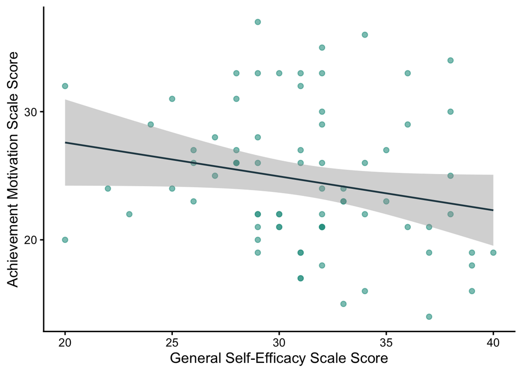

```r
ggplot(
  study_data,
  aes(x = GSE_scale, y = RAM_scale)
) +
  geom_point(alpha = 0.6, size = 2, color = "#2A9D8F") +
  geom_smooth(method = "lm", se = TRUE, color = "#264653", linewidth = 0.8) +
  labs(
    x = "General Self-Efficacy Scale Score",
    y = "Achievement Motivation Scale Score"
  ) +
  theme_classic(base_size = 14)
```

Figure 1 shows the relationship between the General Self-Efficacy and Achievement Motivation scores for all 76 participants. The regression line indicates a slight negative correlation, but the correlation was weak and non-significant (r = −.21, p = .07).

[output not shown]

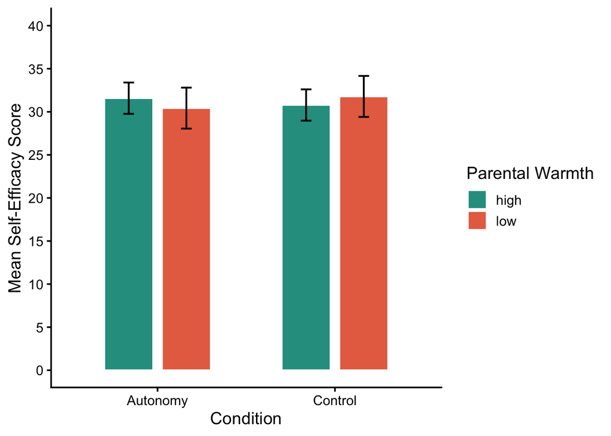

Figure 2. Estimated mean self-efficacy scores by feedback condition (Autonomy vs. Control) and perceived parental warmth group (High vs. Low). Error bars are 95% confidence intervals.

### Achievement Motivation Interaction Plot

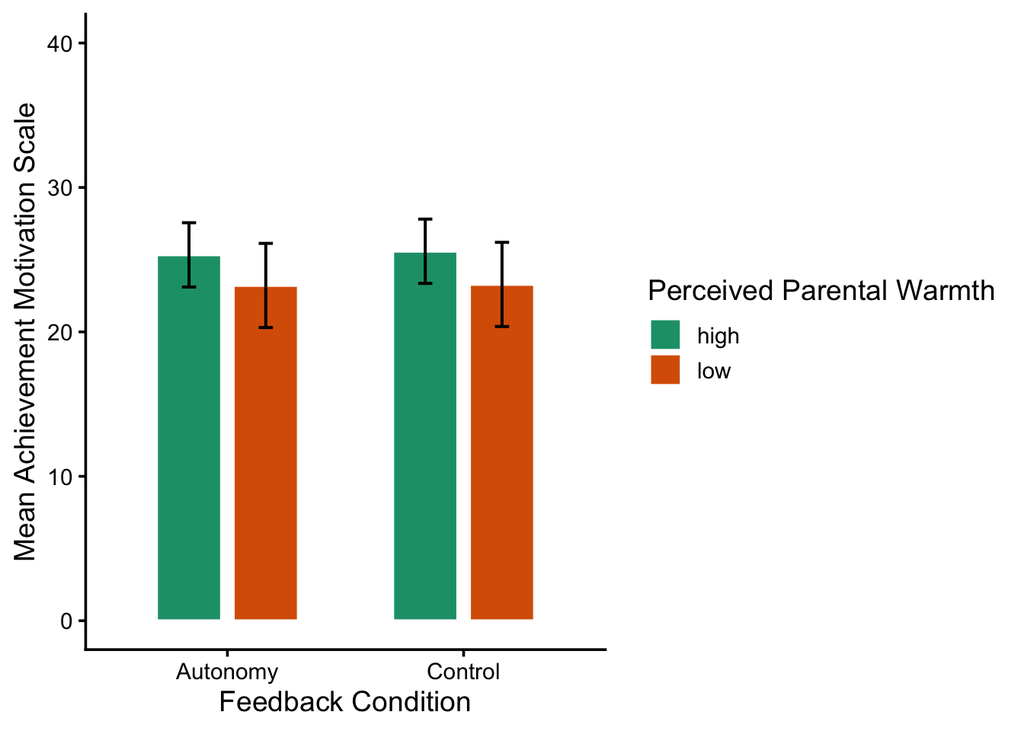

```r
RAM_cell_means <- as.data.frame(
  emmeans(a1_RAM, ~ condition * pwarmth)
)

p_RAM_bar <- ggplot(
  RAM_cell_means,
  aes(
    x = condition,
    y = emmean,
    fill = pwarmth
  )
) +
  geom_col(
    position = position_dodge(width = 0.65),
    width = 0.55,
    color = "white"
  ) +
  geom_errorbar(
    aes(
      ymin = lower.CL,
      ymax = upper.CL
    ),
    position = position_dodge(width = 0.65),
    width = 0.12,
    linewidth = 0.7
  ) +
  labs(
    x = "Feedback Condition",
    y = "Mean Achievement Motivation Scale",
    fill = "Perceived Parental Warmth"
  ) +
  scale_fill_brewer(palette = "Dark2") +
  scale_y_continuous(breaks = seq(0, 40, by = 10)) +
  coord_cartesian(ylim = c(0, 40)) +
  theme_classic(base_size = 14)

p_RAM_bar
```

### Export Figures

```r
if (!dir.exists("figures")) {
  dir.create("figures")
}

ggsave(
  filename = "figures/self_efficacy_interaction_plot.jpg",
  plot = p_SE_bar,
  width = 7,
  height = 5
)

ggsave(
  filename = "figures/achievement_motivation_interaction_plot.jpg",
  plot = p_RAM_bar,
  width = 7,
  height = 5
)
```

## Results Summary

The effect of feedback condition and perceived parental warmth on self-efficacy and achievement motivation was not significant. Students who read autonomy-supportive feedback did not report higher self-efficacy or achievement motivation than those who read controlling feedback. Similarly, the student’s perception of their parental upbringing as either warm or cold did not significantly influence their response to the feedback. These null findings may be related to limitations of the study, such as the use of a hypothetical rather than actual feedback situation, the relatively small sample of college students, or lack of statistical power to detect small effects. In general, the data did not support the predicted effects.